# HAR(Human Activity Recognition) - Predict Correct Method to Lift Dombell

## Part 1: Setup

#### 1.1: Load packages

```r
Packages <- c("tidyverse", "ggplot2", "dplyr", "statsr", "GGally","caret","magrittr",  "purrr", "e1071", "rattle", "nnet", "rpart",  "ipred", "randomForest","gbm" )
lapply(Packages, library, character.only = TRUE)
```

Set seed for the project for reproducability.

```r
set.seed(7777)
```

#### 1.2: Load Data

Data is provided in CSV format at the URL’s provided below. I used `readr::read_csv` function to read the source training and testing data files.

```r
HAR_train_validate <- read_csv("https://d396qusza40orc.cloudfront.net/predmachlearn/pml-training.csv")
HAR_testing <- read_csv("https://d396qusza40orc.cloudfront.net/predmachlearn/pml-testing.csv")
```

#### 1.3: Split Data into Training and Validation Sets

We will create training, validation and testing data sets partitions. We are already given a `testing` data set which we will use for final testing of our algorithm.

We will split our training data set into training and validation data sets by 75/25 split.

```r
trainIndex <- createDataPartition(HAR_train_validate$classe,
                                  p = .75,
                                  list = FALSE,
                                  times = 1)

HAR_training <- HAR_train_validate[trainIndex,]
HAR_validate  <- HAR_train_validate[-trainIndex,]
```

## Part 2: Research Question

These days we can easily collect a large amount of data about different personal activities. In this project, six young healthy participants were asked to perform a set of 10 repetitions of the Unilateral Dumbbell Biceps Curl in five different ways. We collected data by attchig accelerometers on following areas:

- Belt
- Forearm
- Arm
- Dumbell

These 6 participants were asked to perform barbell lifts correctly and incorrectly in 5 different ways. These 5 different ways to lift barbell were recorded in `classe` variable. Given below is the detail of these labels in `classe` variable:

```
Class A - Peformed exercise exactly according to the specification
Class B - Peformed exercise throwing the elbows to the front
Class C - Peformed exercise lifting the dumbbell only halfway
Class D - Peformed exercise lowering the dumbbell only halfway
Class E - Peformed exercise throwing the hips to the front
```

We will try to predict if a person lifted barbell correctly or incorrectly by predicting the `classe` variable by using other varibles in the dataset. We will use training data to train our model and then use validate data to measure the accuracy of our model. Finaly we will do our prediction on 20 test cases prvided to us in the project.

## Part 3: Exploratory Data Analysis and Data Prepration

#### 3.1: Glimpse the dataset

First we will see the types of all varibales provided in the movies data-set.

```r
#glimpse(HAR_training)
```

Complete output of `glimpse` is available in the appendix section. Here we will prvide a quick summary of the varibales.

We notice that there are summary and non-summary variables in the dataset. Summary variables have NA values for most of the rows except few rows where they do provide summary of the other varibles. Folloiwng variables are non-summary variables that have non-NA values for most of the rows, other variables are summary variabes that have mostly NA’s in them:

```
- roll_(Forearm/Belt/Arm/Dumbell)
- pitch_(Forearm/Belt/Arm/Dumbell)
- yaw_(Forearm/Belt/Arm/Dumbell)
- total_accel_(Forearm/Belt/Arm/Dumbell)
- gyros_(Forearm/Belt/Arm/Dumbell)_x
- gyros_(Forearm/Belt/Arm/Dumbell)_y
- gyross_(Forearm/Belt/Arm/Dumbell)_z
- accel_(Forearm/Belt/Arm/Dumbell)_x
- accel_(Forearm/Belt/Arm/Dumbell)_y
- accel_(Forearm/Belt/Arm/Dumbell)_z
- magnet_(Forearm/Belt/Arm/Dumbell)_x
- magnet_(Forearm/Belt/Arm/Dumbell)_y
- magnet_(Forearm/Belt/Arm/Dumbell)_z
```

It seems that we have similiar list of summary and non-summary variables for Belt, Arm and Dumbell accelerators.

#### 3.2: Data Cleanup and Set Correct Datatypes

Now we will make sure that we have correct data types for our columns in our dataset.

we can see that some columns have data types `chr` where it should be set to different data types. This is due to some of the cell in thats variable include “#DIV/0!” value. First we will clean the data by adding NA to the cells which have “#DIV/0!” value and then chnage the type of column to appropiriate datatype instaead of `chr`

```r
HAR_training$cvtd_timestamp  <- as.POSIXct(HAR_training$cvtd_timestamp, format = "%d/%m/%Y %H:%M")
HAR_training$user_name  <- as.factor(HAR_training$user_name)
HAR_training$new_window  <- as.factor(HAR_training$new_window)
HAR_training$classe  <- as.factor(HAR_training$classe)
# Changing chr data types to numeric
HAR_training %<>%
     mutate_if(is.character,as.numeric)


#Perform same for vlidation dataset
HAR_validate$cvtd_timestamp  <- as.POSIXct(HAR_validate$cvtd_timestamp, format = "%d/%m/%Y %H:%M")
HAR_validate$user_name  <- as.factor(HAR_validate$user_name)
HAR_validate$new_window  <- as.factor(HAR_validate$new_window)
HAR_validate$classe  <- as.factor(HAR_validate$classe)
# Changing chr data types to numeric
HAR_validate %<>%
  mutate_if(is.character,as.numeric)


HAR_testing$cvtd_timestamp  <- as.POSIXct(HAR_testing$cvtd_timestamp, format = "%d/%m/%Y %H:%M")
HAR_testing$user_name  <- as.factor(HAR_testing$user_name)
HAR_testing$new_window  <- as.factor(HAR_testing$new_window)
#HAR_testing$classe  <- as.factor(HAR_testing$classe)
# Changing chr data types to numeric
HAR_testing %<>%
  mutate_if(is.character,as.numeric)
```

Next we will create a new dataset containing all non-summary variables for Belt, Arm and Dumbell accelerators. This data set will be used for exploring these variables in more detail and also to creat our predcitive model.

```r
HAR_training_nonSummary <- HAR_training %>%
        select(classe,
               roll_forearm, pitch_forearm, yaw_forearm,total_accel_forearm,
               gyros_forearm_x, gyros_forearm_y, gyros_forearm_z,
               accel_forearm_x, accel_forearm_y, accel_forearm_z,
               magnet_forearm_x, magnet_forearm_y, magnet_forearm_z,

               roll_belt, pitch_belt, yaw_belt,total_accel_belt,
               gyros_belt_x, gyros_belt_y, gyros_belt_z,
               accel_belt_x, accel_belt_y, accel_belt_z,
               magnet_belt_x, magnet_belt_y, magnet_belt_z,

               roll_arm, pitch_arm, yaw_arm,total_accel_arm,
               gyros_arm_x, gyros_arm_y, gyros_arm_z,
               accel_arm_x, accel_arm_y, accel_arm_z,
               magnet_arm_x, magnet_arm_y, magnet_arm_z,

               roll_dumbbell, pitch_dumbbell, yaw_dumbbell,total_accel_dumbbell,
               gyros_dumbbell_x, gyros_dumbbell_y, gyros_dumbbell_z,
               accel_dumbbell_x, accel_dumbbell_y, accel_dumbbell_z,
               magnet_dumbbell_x, magnet_dumbbell_y, magnet_dumbbell_z

        )



HAR_validate_nonSummary <- HAR_validate %>%
        select(classe,
               roll_forearm, pitch_forearm, yaw_forearm,total_accel_forearm,
               gyros_forearm_x, gyros_forearm_y, gyros_forearm_z,
               accel_forearm_x, accel_forearm_y, accel_forearm_z,
               magnet_forearm_x, magnet_forearm_y, magnet_forearm_z,

               roll_belt, pitch_belt, yaw_belt,total_accel_belt,
               gyros_belt_x, gyros_belt_y, gyros_belt_z,
               accel_belt_x, accel_belt_y, accel_belt_z,
               magnet_belt_x, magnet_belt_y, magnet_belt_z,

               roll_arm, pitch_arm, yaw_arm,total_accel_arm,
               gyros_arm_x, gyros_arm_y, gyros_arm_z,
               accel_arm_x, accel_arm_y, accel_arm_z,
               magnet_arm_x, magnet_arm_y, magnet_arm_z,

               roll_dumbbell, pitch_dumbbell, yaw_dumbbell,total_accel_dumbbell,
               gyros_dumbbell_x, gyros_dumbbell_y, gyros_dumbbell_z,
               accel_dumbbell_x, accel_dumbbell_y, accel_dumbbell_z,
               magnet_dumbbell_x, magnet_dumbbell_y, magnet_dumbbell_z

        )



HAR_test_nonSummary <- HAR_testing %>%
        select(roll_forearm, pitch_forearm, yaw_forearm,total_accel_forearm,
               gyros_forearm_x, gyros_forearm_y, gyros_forearm_z,
               accel_forearm_x, accel_forearm_y, accel_forearm_z,
               magnet_forearm_x, magnet_forearm_y, magnet_forearm_z,

               roll_belt, pitch_belt, yaw_belt,total_accel_belt,
               gyros_belt_x, gyros_belt_y, gyros_belt_z,
               accel_belt_x, accel_belt_y, accel_belt_z,
               magnet_belt_x, magnet_belt_y, magnet_belt_z,

               roll_arm, pitch_arm, yaw_arm,total_accel_arm,
               gyros_arm_x, gyros_arm_y, gyros_arm_z,
               accel_arm_x, accel_arm_y, accel_arm_z,
               magnet_arm_x, magnet_arm_y, magnet_arm_z,

               roll_dumbbell, pitch_dumbbell, yaw_dumbbell,total_accel_dumbbell,
               gyros_dumbbell_x, gyros_dumbbell_y, gyros_dumbbell_z,
               accel_dumbbell_x, accel_dumbbell_y, accel_dumbbell_z,
               magnet_dumbbell_x, magnet_dumbbell_y, magnet_dumbbell_z

        )
```

#### 3.3: Remove NA Values

As NA values can cause difficlulties with our modeling algorithim, we will remove any rows with NA values in our non-summary data sets.

```r
# Drop rows with NA's in HAR_training_nonSummary
HAR_training_nonSummary <- HAR_training_nonSummary %>% drop_na()
colnames(HAR_training_nonSummary)[colSums(is.na(HAR_training_nonSummary)) > 0]
```

```
## character(0)
```

There are no rows with NA values left in HAR_training_nonSummary data set.

```r
# Drop rows with NA's in HAR_validate_nonSummary
HAR_validate_nonSummary <- HAR_validate_nonSummary %>% drop_na()
colnames(HAR_validate_nonSummary)[colSums(is.na(HAR_validate_nonSummary)) > 0]
```

```
## character(0)
```

```r
# Drop rows with NA's in HAR_validate_nonSummary
HAR_test_nonSummary <- HAR_test_nonSummary %>% drop_na()
colnames(HAR_test_nonSummary)[colSums(is.na(HAR_test_nonSummary)) > 0]
```

```
## character(0)
```

Also, There are no rows with NA values left in HAR_validate_nonSummary data set.

#### 3.4: Data Distributions

Distrubutions for all non-summary varibales are provided in the appendix section.

#### 3.5: Outliers

after looking at box plots in the appendix section, we dont need to remove any outliers from our dataset.

#### 3.6: Data Normlization

We dont not need to normalize our data as we will be using tree based algorithym such for our modeling and predictions.

## Part 4: Modeling

### 4.1: Model C - RandomForest algorithm using non-summary variables

Next we will try RandomForest algorithm with `ntree = 100` to fit our model and do predictions on our validation and test data sets.

```r
#Model - C Non-Summary Variables Randomforest model

#modelFit_C <- train(classe ~ ., data = HAR_training_nonSummary, method = "rf", ntree = 10)
modelFit_C <- randomForest(classe ~ ., data = HAR_training_nonSummary, method = "rf", ntree = 100)
prediction_C <- predict(modelFit_C, HAR_validate_nonSummary)
confusionMatrix(prediction_C, HAR_validate_nonSummary$classe)
```

```
## Confusion Matrix and Statistics
##
##           Reference
## Prediction    A    B    C    D    E
##          A 1395    5    0    0    0
##          B    0  943    3    0    0
##          C    0    1  852    5    1
##          D    0    0    0  799    1
##          E    0    0    0    0  899
##
## Overall Statistics
##
##                Accuracy : 0.9967
##                  95% CI : (0.9947, 0.9981)
##     No Information Rate : 0.2845
##     P-Value [Acc > NIR] : < 2.2e-16
##
##                   Kappa : 0.9959
##  Mcnemar's Test P-Value : NA
##
## Statistics by Class:
##
##                      Class: A Class: B Class: C Class: D Class: E
## Sensitivity            1.0000   0.9937   0.9965   0.9938   0.9978
## Specificity            0.9986   0.9992   0.9983   0.9998   1.0000
## Pos Pred Value         0.9964   0.9968   0.9919   0.9988   1.0000
## Neg Pred Value         1.0000   0.9985   0.9993   0.9988   0.9995
## Prevalence             0.2845   0.1935   0.1743   0.1639   0.1837
## Detection Rate         0.2845   0.1923   0.1737   0.1629   0.1833
## Detection Prevalence   0.2855   0.1929   0.1752   0.1631   0.1833
## Balanced Accuracy      0.9993   0.9965   0.9974   0.9968   0.9989
```

```r
#print teh model and look at its output
print(modelFit_C)
```

```
##
## Call:
##  randomForest(formula = classe ~ ., data = HAR_training_nonSummary,      method = "rf", ntree = 100)
##                Type of random forest: classification
##                      Number of trees: 100
## No. of variables tried at each split: 7
##
##         OOB estimate of  error rate: 0.58%
## Confusion matrix:
##      A    B    C    D    E  class.error
## A 4181    4    0    0    0 0.0009557945
## B   16 2826    6    0    0 0.0077247191
## C    0   19 2544    4    0 0.0089598753
## D    0    0   25 2384    3 0.0116086235
## E    0    0    3    5 2698 0.0029563932
```

### 4.2: Out Of Bag Error Rates

```r
# Look at final OOB error rate (last row in err matrix)
err <- modelFit_C$err.rate
oob_err <- err[nrow(err), "OOB"]
print(oob_err)
```

```
##         OOB
## 0.005775241
```

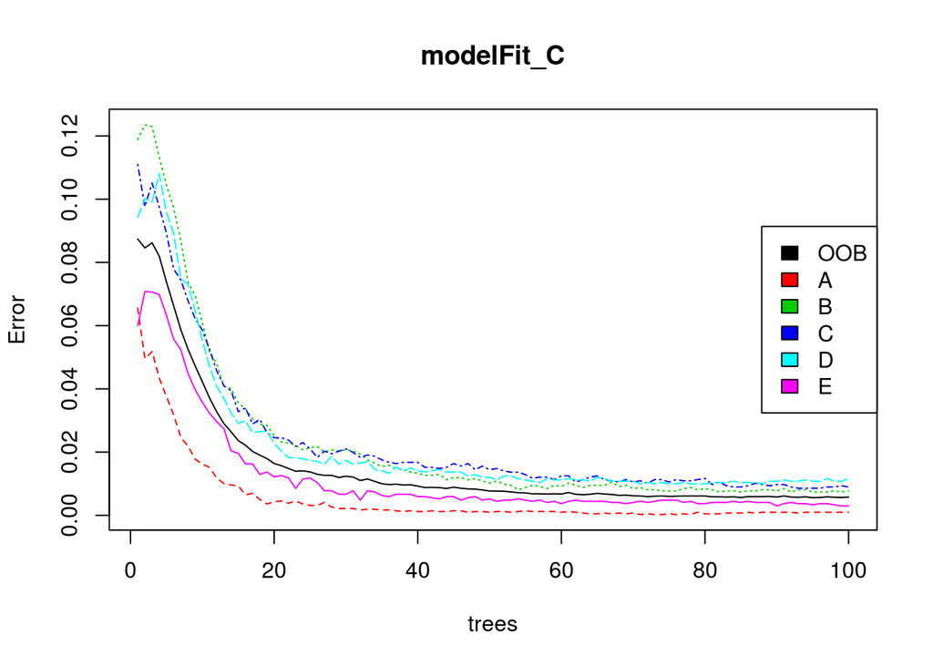

```r
# Plot the model trained in the previous exercise
plot(modelFit_C)
legend(x = "right",
       legend = colnames(err),
       fill = 1:ncol(err))
```

Our lowest OOB error rate is **0.0057**. Also, we can see that Out of Bag error (OOB) becomes flat after 60 trees. So we can use 60 as number `ntrees` of trees for our algorithm.

### 4.3: Fine Tuning Random Forest Algorithm Parameters

Nextt we will try to fine tune our Random Forest model by finding optimal values for parameters such as `mtry`, `nodesize`, `sampsize` using grid parameters. i.e we will try multiple combinations of these values to find the combintaion which will result in the higest model accuracy.

```r
#########################################################
########### Tune all of the mtry, nodesize, sampsize ####
#########################################################

# Establish a list of possible values for mtry, nodesize and sampsize
#mtry <- seq(4, ncol(HAR_training_nonSummary) * 0.8, 2)
mtry <- 7
nodesize <- seq(3, 8, 2)
#nodesize <- 3
sampsize <- nrow(HAR_training_nonSummary) * c(0.7, 0.8)

# Create a data frame containing all combinations
hyper_grid <- expand.grid(mtry = mtry, nodesize = nodesize, sampsize = sampsize)

# Create an empty vector to store OOB error values
oob_err <- c()

# Write a loop over the rows of hyper_grid to train the grid of models
for (i in 1:nrow(hyper_grid)) {

  # Train a Random Forest model
  model <- randomForest(formula = classe ~ .,
                        data = HAR_training_nonSummary,
                        ntree = 60,
                        mtry = hyper_grid$mtry[i],
                        nodesize = hyper_grid$nodesize[i],
                        sampsize = hyper_grid$sampsize[i])

  # Store OOB error for the model
  oob_err[i] <- model$err.rate[nrow(model$err.rate), "OOB"]
}

# Identify optimal set of hyperparmeters based on OOB error
opt_i <- which.min(oob_err)
print(hyper_grid[opt_i,])
```

```
##   mtry nodesize sampsize
## 1    7        3  10302.6
```

For tuning of our RandomForest we can use the following values to produce the best fit model:

[output not shown]

### 4.4: Cross Validation using K-fold with RandomForest Tree Algorithm

Next we will try cross validation using K-fold with using random forest Algorithm to see if we can get a more accurate measure for our accuracy.

```r
train_control <- trainControl(method = "cv", number = 3)   # Cross-validation, 3 K-folds
modelFit_G <- train(classe ~ ., data = HAR_training_nonSummary, trControl=train_control, method = "rf", ntree = 80)
print(modelFit_G)
```

```
## Random Forest
##
## 14718 samples
##    52 predictor
##     5 classes: 'A', 'B', 'C', 'D', 'E'
##
## No pre-processing
## Resampling: Cross-Validated (3 fold)
## Summary of sample sizes: 9811, 9813, 9812
## Resampling results across tuning parameters:
##
##   mtry  Accuracy   Kappa
##    2    0.9881098  0.9849557
##   27    0.9896043  0.9868483
##   52    0.9838970  0.9796286
##
## Accuracy was used to select the optimal model using the largest value.
## The final value used for the model was mtry = 27.
```

We can see that with 3-K cross validation, our accuracy is **Accuracy : 0.98**. There are very few false classification for different class labels for our response varible `classe`.

## Part 5: Predicting Test Data

```r
prediction_test <- predict(modelFit_C, HAR_test_nonSummary)
print(prediction_test)
```

```
##  1  2  3  4  5  6  7  8  9 10 11 12 13 14 15 16 17 18 19 20
##  B  A  B  A  A  E  D  B  A  A  B  C  B  A  E  E  A  B  B  B
## Levels: A B C D E
```

## Apendix

```r
glimpse(HAR_training)
```

```
## Observations: 14,718
## Variables: 160
## $ X1                       <dbl> 1, 2, 3, 4, 7, 9, 10, 11, 12, 13, 15, 1…
## $ user_name                <fct> carlitos, carlitos, carlitos, carlitos,…
## $ raw_timestamp_part_1     <dbl> 1323084231, 1323084231, 1323084231, 132…
## $ raw_timestamp_part_2     <dbl> 788290, 808298, 820366, 120339, 368296,…
## $ cvtd_timestamp           <dttm> 2011-12-05 11:23:00, 2011-12-05 11:23:…
## $ new_window               <fct> no, no, no, no, no, no, no, no, no, no,…
## $ num_window               <dbl> 11, 11, 11, 12, 12, 12, 12, 12, 12, 12,…
## $ roll_belt                <dbl> 1.41, 1.41, 1.42, 1.48, 1.42, 1.43, 1.4…
## $ pitch_belt               <dbl> 8.07, 8.07, 8.07, 8.05, 8.09, 8.16, 8.1…
## $ yaw_belt                 <dbl> -94.4, -94.4, -94.4, -94.4, -94.4, -94.…
## $ total_accel_belt         <dbl> 3, 3, 3, 3, 3, 3, 3, 3, 3, 3, 3, 3, 3, …
## $ kurtosis_roll_belt       <dbl> NA, NA, NA, NA, NA, NA, NA, NA, NA, NA,…
## $ kurtosis_picth_belt      <dbl> NA, NA, NA, NA, NA, NA, NA, NA, NA, NA,…
```

[output cut: 147 more lines]

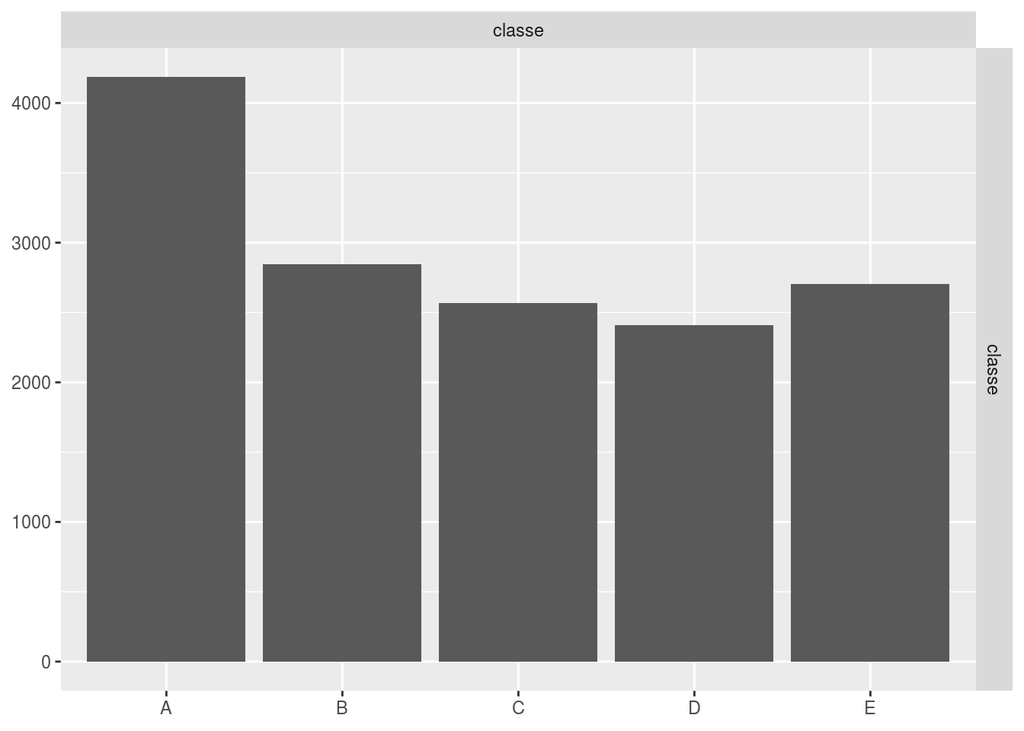

```r
ggpairs(HAR_training_nonSummary, columns = c("classe"))
```

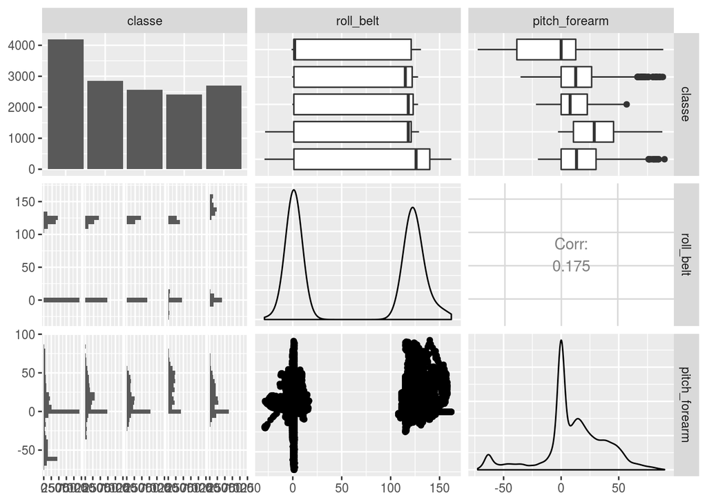

```r
ggpairs(HAR_training_nonSummary, columns = c("classe", "roll_belt", "pitch_forearm"))
```

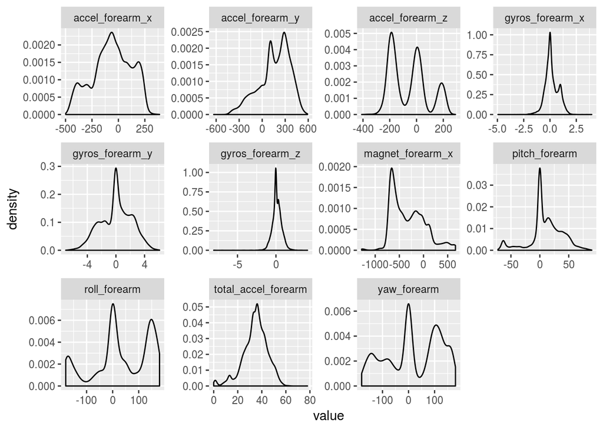

```r
HAR_training_nonSummary %>%
                select(c(2:12)) %>%
                gather() %>%                              # Convert to key-value pairs
                ggplot(aes(value)) +                    # Plot the values
                facet_wrap(~ key, scales = "free") +      # In separate panels
                geom_density()                           # as density
```

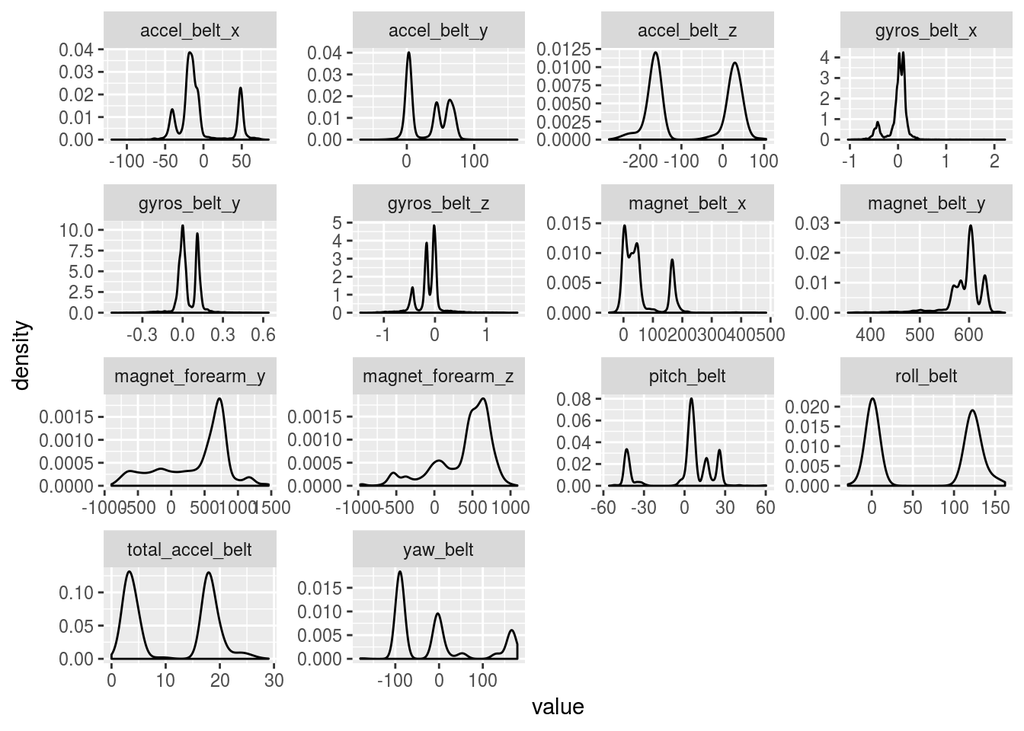

```r
HAR_training_nonSummary %>%
                select(c(13:26)) %>%
                gather() %>%                              # Convert to key-value pairs
                ggplot(aes(value)) +                      # Plot the values
                facet_wrap(~ key, scales = "free") +      # In separate panels
                geom_density()                            # as density
```

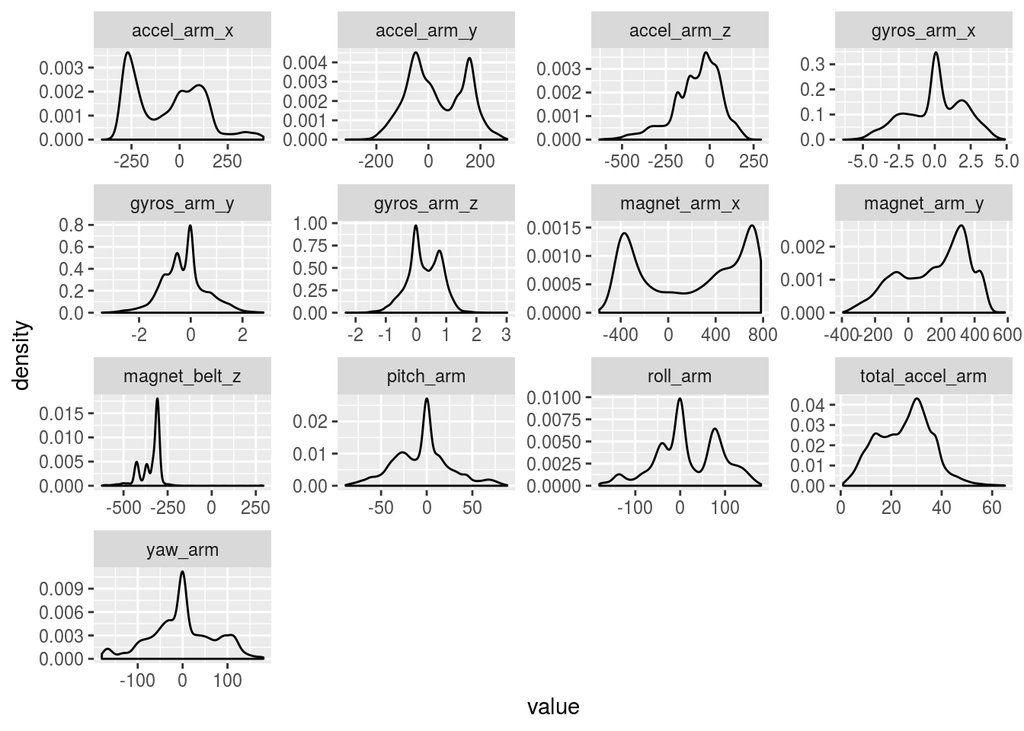

```r
HAR_training_nonSummary %>%
                select(c(27:39)) %>%
                gather() %>%                              # Convert to key-value pairs
                ggplot(aes(value)) +                      # Plot the values
                facet_wrap(~ key, scales = "free") +      # In separate panels
                geom_density()                            # as density
```

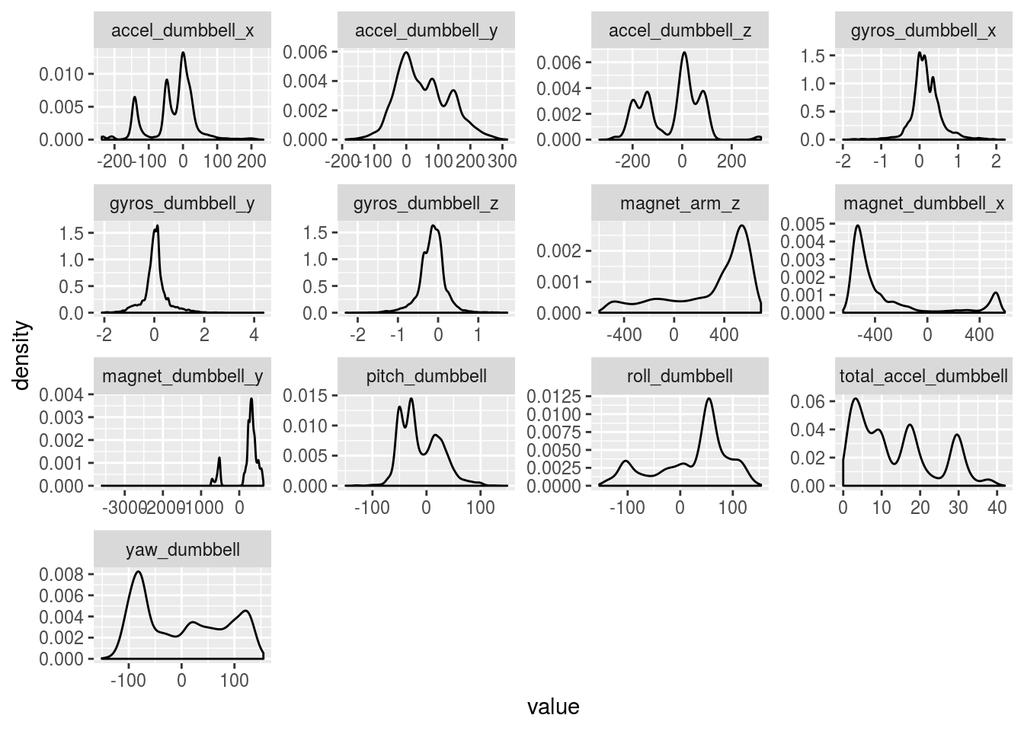

```r
HAR_training_nonSummary %>%
                select(c(40:52)) %>%
                gather() %>%                              # Convert to key-value pairs
                ggplot(aes(value)) +                      # Plot the values
                facet_wrap(~ key, scales = "free") +      # In separate panels
                geom_density()                            # as density
```

#### Outliers

We will draw boxplots of our non-summary variables to see if there are any outliers in the dataset and if they need to be removed ahead of our modeling exercise.

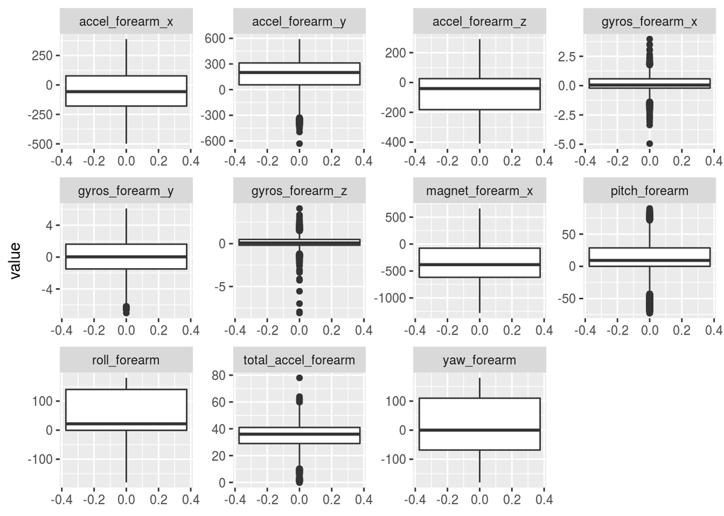

```r
#######################################################################################

HAR_training_nonSummary %>%
                select(c(2:12)) %>%
                gather() %>%                              # Convert to key-value pairs
                ggplot(aes(y = value)) +                    # Plot the values
                facet_wrap(~ key, scales = "free") +      # In separate panels
#               geom_density()                           # as density
                geom_boxplot()                            # as boxplot
```

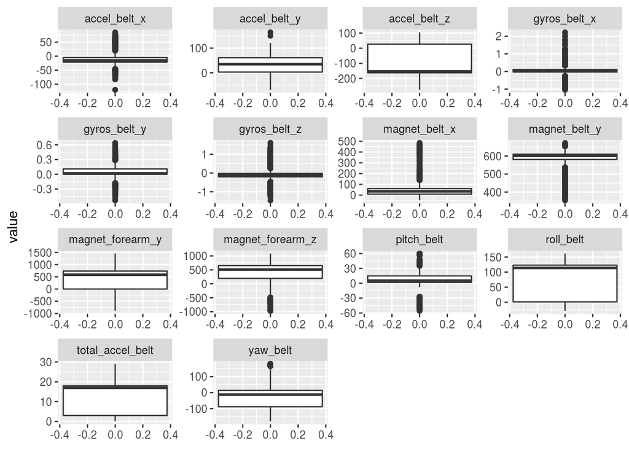

```r
HAR_training_nonSummary %>%
                select(c(13:26)) %>%
                gather() %>%                              # Convert to key-value pairs
                ggplot(aes(y = value)) +                    # Plot the values
                facet_wrap(~ key, scales = "free") +      # In separate panels
#                geom_density()                           # as density
                geom_boxplot()
```

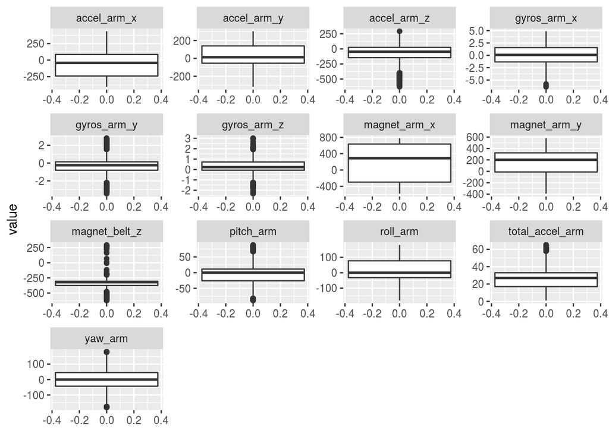

```r
HAR_training_nonSummary %>%
                select(c(27:39)) %>%
                gather() %>%                              # Convert to key-value pairs
                ggplot(aes(y = value)) +                    # Plot the values
                facet_wrap(~ key, scales = "free") +      # In separate panels
#                geom_density()                           # as density
                geom_boxplot()
```

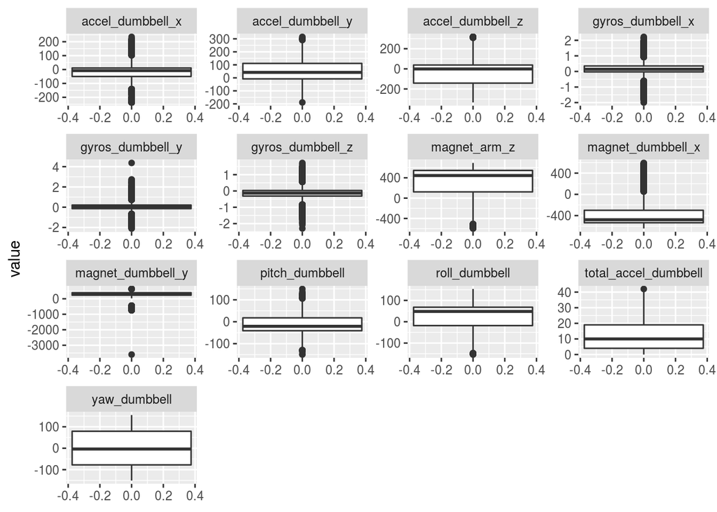

```r
HAR_training_nonSummary %>%
                select(c(40:52)) %>%
                gather() %>%                              # Convert to key-value pairs
                ggplot(aes(y = value)) +                    # Plot the values
                facet_wrap(~ key, scales = "free") +      # In separate panels
#                geom_density()                           # as density
                geom_boxplot()
```